# Assignment 1 Feedback

Victor M. Poulsen

22-02-2020

# Point 1 (Prior influence).

You all got this point, just wanted to say that this was cool. Given a prior with a certain amount of information (confidence) the prior will influence the posterior distribution less when we have more data (stronger likelihood). Direct consequence of the posterior being a weighted sum of the likelihood and the prior.

# Point 2 (fitted vs. predicted).

Most of you already have a good grasp of when we work with fitted values of parameters (e.g. prior, likelihood, posterior) and when we work with predictive values. However, there was some confusion in some groups. (In this case when we do not work with actual models in brms, we get samples from parameters with sample() and predictive prior and posterior with rbinom(n = …, size = …, prob = …).

E.g. some groups showed actual predictions (it seems) when asked to show their prior/posterior, and some groups said that they compared predictions when they actually showed samples from parameters (or fitted values from params). So - let us just briefly talk about this.

So, for the 2a question “show plots of the prior / posterior” what you want is to show the actual parameter values (not predictions). In this case, all of our parameter values (prior) but also likelihood and posterior are bounded within [0, 1].

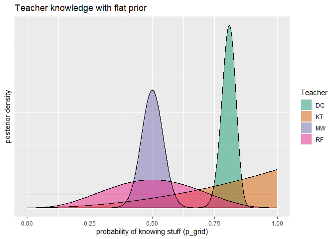

```r
# 2a. Produce plots of the prior, and posterior for each teacher

# set working directory.
# you'll have to change this of course (sorry).
setwd("C:/Users/95/Dropbox/MastersSem2/CompModTA/ModelingFeedback/A1-feedback")

# packages
pacman::p_load(tidyverse, RColorBrewer, wesanderson, cowplot)

# load some data I created (ngrid = 1e4) and flat prior.
d <- read_csv("prior_posterior.csv") %>%
  glimpse()
# n_grid
n_grid = 1e4

# plot of prior (shared) and posteriors (individual for teachers).
d %>%
  ggplot(aes(x = p_grid, ymin = 0, ymax = posterior, fill = Teacher)) +
    geom_ribbon(alpha = 0.5) +
    geom_line(aes(x = p_grid, y = posterior)) +
    geom_line(aes(x = p_grid, y = prior/n_grid), color = "red") +
    scale_fill_brewer(palette = "Dark2") +
    labs(title = "Teacher knowledge with flat prior",
         y = "posterior density",
         x = "probability of knowing stuff (p_grid)") +
    theme(axis.ticks.y=element_blank(),
          axis.text.y=element_blank())
```

# Point 3: comparing two data-collections (visually).

Many of you did this in reasonable fashion. Just wanted to show one way where it becomes really obvious how the posterior is a weighted sum of the prior and likelihood.

# Plotting function (collapsed).

```r
# First: visually comparing the two data collections:
plot_fun2 <- function(d, teacher){

  p <- d %>%
    filter(Teacher == teacher) %>%
    mutate(likelihood = likelihood/sum(likelihood)) %>%
    pivot_longer(cols = prior:posterior) %>%
    mutate(distribution = as_factor(name)) %>%
    ggplot(aes(x = p_grid, ymin = 0,
               ymax = value, fill = distribution)) +
    geom_ribbon(alpha = 0.5) +
    scale_fill_manual(values = wes_palette("Cavalcanti1")) +
    theme(axis.text.x=element_blank(),
          axis.text.y=element_blank(),
          axis.title.x=element_blank()) +
    labs(title = teacher)

  return(p)

}
```

```r
# load some data I created based on initial
# flat prior and then updated with the new data.
d1 <- read_csv("new_posterior.csv")
```

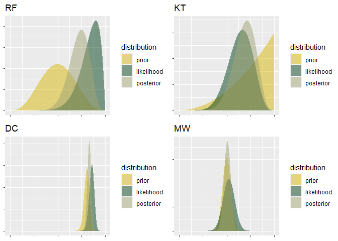

```r
# plot inspired by "recoded" (thanks Paul).
# Generate a plot for each teacher and then plot_grid.
Riccardo <- plot_fun2(d1, "RF")
Tylen <- plot_fun2(d1, "KT")
Daina <- plot_fun2(d1, "DC")
Mikkel <- plot_fun2(d1, "MW")
plot_grid(Riccardo, Tylen, Daina, Mikkel)
```

# Point 4: (Evaluating new data in last years predictive posterior).

```r
pacman::p_load(tidybayes, bayestestR)

# load predictive posterior values.
# again based on flat prior and ngrid = 1e4.
p_post <- read_csv("p_post.csv")
```

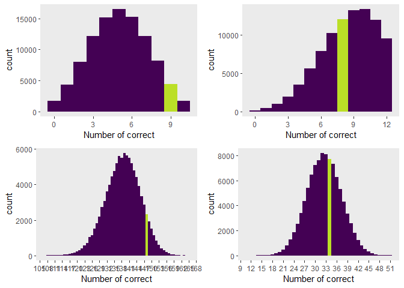

```r
# recall our (new) data:
d2 <- tibble(
  Correct = c(9, 8, 148, 34),
  Questions = c(10, 12, 172, 65),
  Teacher = c("RF", "KT", "DC", "MW")
)

# we can do a plot (which many of you did).
plot_fun3 <- function(teacher, df1, df2){

  p <- df1 %>%
    filter(Teacher == teacher) %>%
    ggplot(aes(x = prediction)) +
    geom_histogram(aes(fill = prediction == df2 %>%
                         filter(Teacher == teacher) %>%
                         pull(Correct)),
                 binwidth = 1, center = 0) +
    scale_x_continuous("Number of correct",
                       breaks = seq(from = 0,
                                    to = df2 %>%
                                      filter(Teacher == teacher) %>%
                                      pull(Questions),
                                    by = 3)) +
    scale_fill_viridis_d(option = "D", end = .9) +
    theme(panel.grid = element_blank(),
          legend.position = "none")

}

# use the function
Riccardo <- plot_fun3("RF", p_post, d2)
Tylen <- plot_fun3("KT", p_post, d2)
Daina <- plot_fun3("DC", p_post, d2)
Wallentin <- plot_fun3("MW", p_post, d2)

# plot grid
plot_grid(Riccardo, Tylen, Daina, Wallentin)
```

```r
# but how do we evaluate this?
# credibility (HDI) intervals is a good idea (many different packages).
p_post %>% group_by(Teacher) %>% summarize(
  l_89 = bayestestR::hdi(prediction, ci = .89, verbose = FALSE)[[2]],
  u_89 = bayestestR::hdi(prediction, ci = .89, verbose = FALSE)[[3]],
  mean = mean(prediction, na.rm = T),
  sd = sd(prediction, na.rm = T)
)
```

[output not shown]

```r
# you could also do a nice plot here with the density intervals.
```

Riccardo vs. the other teachers. Lots of good ideas. One of the good things about bayesian stats is that we have a generative model - and we can generate both samples directly from our prior/posterior (& other potential params) & we can generate predictions from our prior/posterior distributions. A nice measure that I don’t think that McElreath mentions is the probability of superiority.

## 1) Riccardo vs. the other teachers (samples) from parameter.

```r
# load our data
# this is uniform prior with ngrid = 1e4.
g_uniform <- read_csv("g_uniform.csv")
```

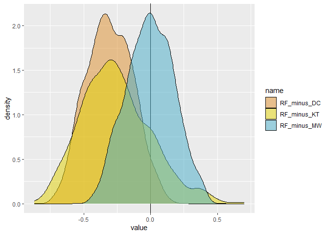

```r
## generate samples
s_uniform <- g_uniform %>%
  group_by(Teacher) %>%
  slice_sample(n = 1000,
               weight_by = posterior,
               replace = T)

# subset_function
subset_fun <- function(df, teacher){

  sub <- df %>%
    filter(Teacher == teacher) %>%
    rename_all(paste0, teacher) %>%

  return(sub)
}

## create subsets (could probably be done smarter).
DC <- subset_fun(s_uniform, "DC")
RF <- subset_fun(s_uniform, "RF")
MW <- subset_fun(s_uniform, "MW")
KT <- subset_fun(s_uniform, "KT")

## cbind, select, pivot & plot (could be prettier of course).
cbind(DC, RF, MW, KT) %>%
  mutate(RF_minus_DC = p_gridRF - p_gridDC,
         RF_minus_MW = p_gridRF - p_gridMW,
         RF_minus_KT = p_gridRF - p_gridKT) %>%
  ungroup() %>%
  select(RF_minus_DC,
         RF_minus_KT,
         RF_minus_MW) %>%
  pivot_longer(everything()) %>%
  ggplot(aes(fill = name)) +
  geom_vline(xintercept = 0) +
  geom_density(aes(x = value, group = name), alpha = 0.5) +
  scale_fill_manual(values = wes_palette("FantasticFox1"))
```

## 1) Riccardo vs. the other teachers.

## predictive posterior - probability of superiority.

```r
# just a function to get predictive posterior.
# NB: size = 1 in rbinom() as we would want with probability of superiority.
# If you want to look at the probability that any teacher answers more
# questions correctly than Riccardo when they are asked 10 questions instead
# of 1 question then you can change this value.
pred_post <- function(d_new, samples){

  # empty placeholder
  grid_teacher2 <- tibble()

  # main loop
  for(i in d_new$Teacher){

    g <- tibble(
      prediction = rbinom(n = samples,
                          size = 1, #total questions (new data)
                           prob = rnorm(
                             n = samples,
                             mean = d_new %>%
                               filter(Teacher == i) %>%
                               pull(Estimate),
                             sd = d_new %>%
                               filter(Teacher == i) %>%
                               pull(SD))), #from hdi (old data)
      Teacher = i)

    grid_teacher2 <- bind_rows(grid_teacher2, g)

  }

  return(grid_teacher2)
}

# get our values out from samples.
s_uniform %>% group_by(Teacher) %>% summarize(
  mean = mean(p_grid, na.rm = T),
  sd = sd(p_grid, na.rm = T)
)
# use these values
d2 <- tibble(
  Estimate = c(0.5, 0.738, 0.805, 0.5),
  SD = c(0.169, 0.198, 0.0272, 0.0425),
  Teacher = c("RF", "KT", "DC", "MW")
)

# size
samples <- 1e5

# run the function (NA when prob > 1 OR prob < 0).
p_posterior <- pred_post(d2, samples) %>%
  na.omit()
```

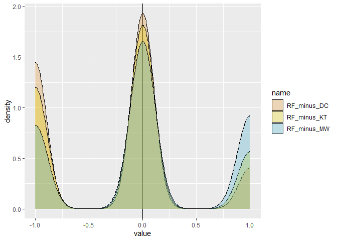

```r
# subset_function
subset_fun <- function(df, teacher){

  sub <- df %>%
    filter(Teacher == teacher) %>%
    rename_all(paste0, teacher) %>%
    slice_head(n = 5000)

  return(sub)
}

## create subsets
DC <- subset_fun(p_posterior, "DC")
RF <- subset_fun(p_posterior, "RF")
MW <- subset_fun(p_posterior, "MW")
KT <- subset_fun(p_posterior, "KT")

# does not work as well for discrete outcomes I must say.
# this would be nice for a continuous outcome.
# also probably should not be a density plot.
cbind(DC, RF, MW, KT) %>%
  mutate(RF_minus_DC = predictionRF - predictionDC,
         RF_minus_MW = predictionRF - predictionMW,
         RF_minus_KT = predictionRF - predictionKT) %>%
  ungroup() %>%
  select(RF_minus_DC,
         RF_minus_KT,
         RF_minus_MW) %>%
  pivot_longer(everything()) %>%
  ggplot(aes(fill = name)) +
  geom_vline(xintercept = 0) +
  geom_density(aes(x = value, group = name), alpha = 0.3) +
  scale_fill_manual(values = wes_palette("FantasticFox1"))
```